# Systolic blood pressure in Kenyan outpatient attenders

Dataset 4: Kenya hypertension screening survey

RSR feasibility analysis

2026-08-03

# Introduction

Hypertension is the leading modifiable cardiovascular risk factor in sub-Saharan Africa, and Kenya’s national NCD strategy relies on opportunistic screening of people already attending health facilities rather than on population surveys. This dataset is a cross-sectional screening survey of 1444 adults recruited at three types of outpatient facility in Kenya - a government (public) facility, a private facility and a faith-based mission facility - in which every participant had blood pressure measured three times and completed a WHO STEPS-style questionnaire on demography, behaviour and self-reported morbidity. Systolic pressure is modelled here as a continuous quantity because it is the measurement that drives stroke and ischaemic heart disease risk, and dichotomising it discards information.

**Aim.** Among these Kenyan outpatient attenders, we examined which of age band, sex, education, BMI category, current smoking, current alcohol use, physical activity and self-reported diabetes are independently associated with average systolic blood pressure, mutually adjusting for the others.

This is a *Purpose 3* analysis: several predictors are of interest and the question is which remain associated with the outcome after mutual adjustment.

# Methods

**Data source.** A cross-sectional facility-based screening survey of 1444 adults aged 18 and over attending outpatient services at three Kenyan facilities (450 public, 557 private, 437 faith-based). Blood pressure was taken three times per participant and the file carries the average of the three readings.

**Variables.** The outcome is `systolic_bp`, the mean of three systolic readings in mmHg, treated as continuous (observed range 79 to 225 mmHg). Predictors are age band (reference *26-35*, the largest band); sex (reference *Female*); education (reference *No School*); WHO BMI category (reference *Healthy*); current smoking (reference *No*); current alcohol use (reference *No*); meeting the physical-activity recommendation (reference *No*); and self-reported diabetes (reference *no*, with *unknown* retained as a substantive third level rather than treated as missing).

**BMI is categorical, not continuous.** The file contains only the WHO `bmi_category` label, not the underlying height, weight or BMI value. It is therefore impossible to report a per-unit BMI effect (mmHg per kg/m2) from these data; every adiposity result below is a contrast between broad WHO bands, and the bands are wide enough that residual confounding by adiposity within band is certain. In fact **no predictor in this file is continuous** - even age is supplied only as a six-level band - so this linear model is a cell-means (ANOVA-style) model throughout and no slope-per-unit statement of any kind can be made.

**Variables deliberately excluded.** `hypertension` is *not* an independent variable: it is defined as measured average blood pressure crossing the diagnostic threshold, so it is a deterministic function of the outcome and `diastolic_bp`. Regressing systolic pressure on it would be regressing the outcome on a coarsened copy of itself. `diastolic_bp` is excluded for the same reason - it is the other half of the same measurement, correlates with systolic pressure at r = 0.71, and is a co-outcome rather than an exposure. `prior_htn_diagnosis` is excluded from the main model and examined separately in a sensitivity analysis, because people who already carry a diagnosis are likely to be on treatment, which *lowers* measured pressure; that variable therefore sits downstream of the outcome as much as upstream of it. `monthly_income` is excluded from the main model on missing-data grounds and its cost is quantified below.

**Statistical analysis.** `lm()`, justified because the outcome is a continuous, roughly unimodal measurement. We fitted a univariable model for each predictor first, then a single multivariable model containing all eight. Predictors were chosen in advance on subject-matter grounds, not by significance. Significance threshold 0.05; estimates are reported with 95% confidence intervals. Assumptions were checked with `performance::check_model()`, and because non-constant variance was flagged we additionally report HC3 heteroscedasticity-consistent standard errors. Analysis used R version 4.6.0 (2026-04-24) with tidyverse, gtsummary and performance.

**Missing data.** Complete-case analysis: 1376 of 1444 rows were analysed (68 dropped, 4.7%). Missingness in this file is extremely uneven. The outcome and four of the predictors are 100% complete; the losses come from `bmi_category` (31 missing), `education` (21) and `age_group` (17). The one seriously incomplete variable is `monthly_income`, missing for 453 participants (31.4%), which is why it is not in the main model; the section *The cost of `monthly_income`* below reports what including it would do.

# Results

## Sample characteristics

**Table 1. Sample characteristics, complete-case analytic sample.**

| **Characteristic** | **N** | **N = 1,376**<sup>1</sup> |
| --- | --- | --- |
| Systolic BP (mmHg) | 1,376 | 126 (115, 140) |
| Age band (years) | 1,376 |  |
| 26-35 |  | 287 (21%) |
| 18-25 |  | 100 (7.3%) |
| 36-45 |  | 274 (20%) |
| 46-55 |  | 256 (19%) |
| 56-65 |  | 242 (18%) |
| >65 |  | 217 (16%) |
| Sex | 1,376 |  |
| Female |  | 741 (54%) |
| Male |  | 635 (46%) |
| Education | 1,376 |  |
| No School |  | 178 (13%) |
| Primary |  | 234 (17%) |
| Secondary |  | 363 (26%) |
| Tertiary |  | 601 (44%) |
| BMI category (WHO) | 1,376 |  |
| Healthy |  | 547 (40%) |
| Underweight |  | 80 (5.8%) |
| Overweight |  | 444 (32%) |
| Obese |  | 305 (22%) |
| Current smoker | 1,376 | 89 (6.5%) |
| Current alcohol use | 1,376 | 114 (8.3%) |
| Meets activity recommendation | 1,376 | 615 (45%) |
| Self-reported diabetes | 1,376 |  |
| no |  | 937 (68%) |
| yes |  | 187 (14%) |
| unknown |  | 252 (18%) |

<sup>1</sup> Median (Q1, Q3); n (%)

Median systolic pressure is 126.3 mmHg (IQR 115.3 to 140.0), with a long right tail reaching 225 mmHg. The sample is predominantly female (54%) and better educated than the Kenyan adult population (44% tertiary), which is a facility-attender rather than a community sample. 54% are overweight or obese, while current smoking (6.5%) and current alcohol use (8.3%) are rare.

## Exploratory figure

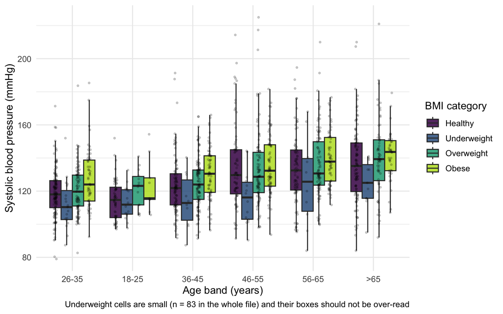

Figure 1. Systolic blood pressure by age band and WHO BMI category. Boxes are medians and IQRs; points are individual participants.

Systolic pressure rises across successive age bands within every BMI category, and within each age band the obese sit above the healthy-weight group, so the two gradients are at least partly independent; the spread of pressures also widens noticeably in the older bands, which is the first hint of the non-constant variance confirmed in the diagnostics.

## Univariable models

| **Characteristic** | **N** | **Beta** | **95% CI** | **p-value** |
| --- | --- | --- | --- | --- |
| Age band (years) | 1,376 |  |  |  |
| 26-35 |  | — | — |  |
| 18-25 |  | -4.4 | -8.7, -0.06 | 0.047 |
| 36-45 |  | 5.0 | 1.9, 8.1 | 0.002 |
| 46-55 |  | 13 | 9.8, 16 | <0.001 |
| 56-65 |  | 15 | 12, 19 | <0.001 |
| >65 |  | 17 | 14, 20 | <0.001 |
| Sex | 1,376 |  |  |  |
| Female |  | — | — |  |
| Male |  | 2.9 | 0.78, 5.1 | 0.008 |
| Education | 1,376 |  |  |  |
| No School |  | — | — |  |
| Primary |  | 6.7 | 2.9, 11 | <0.001 |
| Secondary |  | 2.8 | -0.74, 6.4 | 0.12 |
| Tertiary |  | -3.3 | -6.7, -0.01 | 0.049 |
| BMI category (WHO) | 1,376 |  |  |  |
| Healthy |  | — | — |  |
| Underweight |  | -10 | -15, -5.5 | <0.001 |
| Overweight |  | 3.3 | 0.85, 5.8 | 0.009 |
| Obese |  | 7.6 | 4.9, 10 | <0.001 |
| Current smoker | 1,376 |  |  |  |
| No |  | — | — |  |
| Yes |  | 3.0 | -1.3, 7.4 | 0.2 |
| Current alcohol use | 1,376 |  |  |  |
| No |  | — | — |  |
| Yes |  | 2.1 | -1.8, 6.0 | 0.3 |
| Meets activity recommendation | 1,376 |  |  |  |
| No |  | — | — |  |
| Yes |  | -0.97 | -3.1, 1.2 | 0.4 |
| Self-reported diabetes | 1,376 |  |  |  |
| no |  | — | — |  |
| yes |  | 6.2 | 3.0, 9.4 | <0.001 |
| unknown |  | -0.12 | -2.9, 2.7 | >0.9 |

Abbreviation: CI = Confidence Interval

Age dominates. Relative to the 26-35 band, participants over 65 average 17.08 mmHg (95% CI 13.74 to 20.42) higher systolic pressure (p < 0.001), with a monotonic gradient through the intermediate bands (13.01 mmHg (95% CI 9.82 to 16.20) at 46-55, 15.37 mmHg (95% CI 12.13 to 18.61) at 56-65). Obesity is the next largest crude signal: obese participants average 7.64 mmHg (95% CI 4.85 to 10.42) higher pressure than healthy-weight participants (p < 0.001), and underweight participants -10.18 mmHg (95% CI -14.84 to -5.52) (p < 0.001). Men average 2.92 mmHg (95% CI 0.78 to 5.06) higher than women (p = 0.008). Self-reported diabetes carries 6.21 mmHg (95% CI 3.05 to 9.38) crudely (p < 0.001). Education is non-monotonic in the crude analysis: primary schooling sits 6.74 mmHg (95% CI 2.85 to 10.62) above no schooling (p < 0.001) while tertiary sits -3.34 mmHg (95% CI -6.68 to -0.01) (p = 0.049). Smoking, alcohol and physical activity show no crude association.

## Why adjustment is needed

The crude estimates above are not comparable with one another because the predictors are strongly interlocked in this sample. **Age band** is the obvious confounder: it is the strongest determinant of systolic pressure through arterial stiffening, and it is also associated with almost every other predictor here - diabetes prevalence rises steeply with age (19% of the over-65s report diabetes versus 5% of the 26-35 band), obesity accumulates with age, and education is far lower in the older bands (31% of over-65s never attended school versus 11% of 26-35s). The crude diabetes coefficient of about 6.2 mmHg is therefore in large part an age difference between people with and without diabetes, and the crude “protective” tertiary-education coefficient is in large part the youth of the tertiary-educated. **Sex** confounds both behavioural exposures: smoking is almost entirely male in this sample (81 of 89 smokers are men) and so is alcohol use, while men also have higher pressure at a given age, so the crude smoking and alcohol coefficients are partly sex coefficients. **BMI category** confounds the diabetes and activity contrasts in turn, since adiposity causes both insulin resistance and raised pressure. Mutual adjustment lets each coefficient be read as a comparison between participants who are alike on the other seven measured characteristics.

## Multivariable model

| **Characteristic** | **Beta** | **95% CI** | **p-value** |
| --- | --- | --- | --- |
| Age band (years) |  |  |  |
| 26-35 | — | — |  |
| 18-25 | -3.1 | -7.4, 1.2 | 0.2 |
| 36-45 | 3.1 | 0.01, 6.2 | 0.049 |
| 46-55 | 11 | 7.6, 14 | <0.001 |
| 56-65 | 12 | 8.8, 16 | <0.001 |
| >65 | 15 | 11, 18 | <0.001 |
| Sex |  |  |  |
| Female | — | — |  |
| Male | 2.9 | 0.76, 5.0 | 0.008 |
| Education |  |  |  |
| No School | — | — |  |
| Primary | 6.3 | 2.3, 10 | 0.002 |
| Secondary | 4.0 | 0.12, 7.9 | 0.043 |
| Tertiary | -0.27 | -4.2, 3.6 | 0.9 |
| BMI category (WHO) |  |  |  |
| Healthy | — | — |  |
| Underweight | -10 | -14, -5.6 | <0.001 |
| Overweight | 2.7 | 0.28, 5.0 | 0.028 |
| Obese | 7.3 | 4.6, 10 | <0.001 |
| Current smoker |  |  |  |
| No | — | — |  |
| Yes | -0.41 | -4.6, 3.8 | 0.8 |
| Current alcohol use |  |  |  |
| No | — | — |  |
| Yes | 3.0 | -0.69, 6.8 | 0.11 |
| Meets activity recommendation |  |  |  |
| No | — | — |  |
| Yes | 0.38 | -1.6, 2.4 | 0.7 |
| Self-reported diabetes |  |  |  |
| no | — | — |  |
| yes | 0.75 | -2.2, 3.7 | 0.6 |
| unknown | 1.2 | -1.9, 4.2 | 0.5 |

Abbreviation: CI = Confidence Interval

**Model fit: multivariable linear model for systolic BP**

| Statistic | Value |
| --- | --- |
| Complete-case N | 1376 |
| Rows dropped by listwise deletion | 68 |
| Parameters (excl. intercept) | 17 |
| R-squared | 0.180 |
| Adjusted R-squared | 0.170 |
| Residual SE (mmHg) | 18.46 |
| AIC | 11948.0 |

The model was fitted on 1376 complete cases and explains 18.0% of the variance in systolic pressure (adjusted R-squared 0.170, residual SE 18.5 mmHg). The gap between R-squared and adjusted R-squared is small, so the 17 parameters are not being bought at a meaningful cost in overfitting. Among participants of the same sex, education, BMI category, smoking, drinking, activity and diabetes status, the over-65s average 14.67 mmHg (95% CI 11.05 to 18.29) higher systolic pressure than the 26-35 band (p < 0.001), and the 46-55 band 10.86 mmHg (95% CI 7.64 to 14.07) (p < 0.001). Obesity retains 7.32 mmHg (95% CI 4.60 to 10.05) (p < 0.001) and underweight -10.05 mmHg (95% CI -14.49 to -5.61) (p < 0.001). Men average 2.90 mmHg (95% CI 0.76 to 5.03) higher than women of the same age and body size (p = 0.008). Diabetes is essentially null after adjustment (0.75 mmHg (95% CI -2.25 to 3.75), p = 0.624). These are associations among the participants observed, not effects of intervening on any of these variables.

## The cost of `monthly_income`

**Table 2. What adding `monthly_income` costs.**

`monthly_income` is missing for 31% of participants; listwise deletion removes them from the whole model, not just from that one coefficient.

| Model | N | % of file | Parameters | R-squared | Adj. R-squared |
| --- | --- | --- | --- | --- | --- |
| Main model (no income) | 1376 | 95.3 | 17 | 0.180 | 0.170 |
| Same model, income complete-cases only | 968 | 67.0 | 17 | 0.197 | 0.183 |
| Model with monthly_income added | 968 | 67.0 | 21 | 0.198 | 0.180 |

This is the single most important methodological point in this dataset. `monthly_income` is missing for 31.4% of participants, and because `lm()` deletes rows listwise, adding it removes those participants from *every* coefficient in the model, not only from the income coefficient. The complete-case N falls from **1376** to **968** (67% of the file): 408 further participants are discarded, at a cost of 4 extra parameters. Income adds essentially nothing in exchange - the F-test comparing the two models on the *same* 968 rows gives p = 0.982, and adjusted R-squared moves from 0.183 to 0.180.

## Unadjusted versus adjusted

**Table 3. Unadjusted and adjusted estimates.**

| **Characteristic** | **Unadjusted** **N** | **Unadjusted** **Beta** | **Unadjusted** **95% CI** | **Unadjusted** **p-value** | **Adjusted** **Beta** | **Adjusted** **95% CI** | **Adjusted** **p-value** |
| --- | --- | --- | --- | --- | --- | --- | --- |
| Age band (years) | 1,376 |  |  |  |  |  |  |
| 26-35 |  | — | — |  | — | — |  |
| 18-25 |  | -4.4 | -8.7, -0.06 | 0.047 | -3.1 | -7.4, 1.2 | 0.2 |
| 36-45 |  | 5.0 | 1.9, 8.1 | 0.002 | 3.1 | 0.01, 6.2 | 0.049 |
| 46-55 |  | 13 | 9.8, 16 | <0.001 | 11 | 7.6, 14 | <0.001 |
| 56-65 |  | 15 | 12, 19 | <0.001 | 12 | 8.8, 16 | <0.001 |
| >65 |  | 17 | 14, 20 | <0.001 | 15 | 11, 18 | <0.001 |
| Sex | 1,376 |  |  |  |  |  |  |
| Female |  | — | — |  | — | — |  |
| Male |  | 2.9 | 0.78, 5.1 | 0.008 | 2.9 | 0.76, 5.0 | 0.008 |
| Education | 1,376 |  |  |  |  |  |  |
| No School |  | — | — |  | — | — |  |
| Primary |  | 6.7 | 2.9, 11 | <0.001 | 6.3 | 2.3, 10 | 0.002 |
| Secondary |  | 2.8 | -0.74, 6.4 | 0.12 | 4.0 | 0.12, 7.9 | 0.043 |
| Tertiary |  | -3.3 | -6.7, -0.01 | 0.049 | -0.27 | -4.2, 3.6 | 0.9 |
| BMI category (WHO) | 1,376 |  |  |  |  |  |  |
| Healthy |  | — | — |  | — | — |  |
| Underweight |  | -10 | -15, -5.5 | <0.001 | -10 | -14, -5.6 | <0.001 |
| Overweight |  | 3.3 | 0.85, 5.8 | 0.009 | 2.7 | 0.28, 5.0 | 0.028 |
| Obese |  | 7.6 | 4.9, 10 | <0.001 | 7.3 | 4.6, 10 | <0.001 |
| Current smoker | 1,376 |  |  |  |  |  |  |
| No |  | — | — |  | — | — |  |
| Yes |  | 3.0 | -1.3, 7.4 | 0.2 | -0.41 | -4.6, 3.8 | 0.8 |
| Current alcohol use | 1,376 |  |  |  |  |  |  |
| No |  | — | — |  | — | — |  |
| Yes |  | 2.1 | -1.8, 6.0 | 0.3 | 3.0 | -0.69, 6.8 | 0.11 |
| Meets activity recommendation | 1,376 |  |  |  |  |  |  |
| No |  | — | — |  | — | — |  |
| Yes |  | -0.97 | -3.1, 1.2 | 0.4 | 0.38 | -1.6, 2.4 | 0.7 |
| Self-reported diabetes | 1,376 |  |  |  |  |  |  |
| no |  | — | — |  | — | — |  |
| yes |  | 6.2 | 3.0, 9.4 | <0.001 | 0.75 | -2.2, 3.7 | 0.6 |
| unknown |  | -0.12 | -2.9, 2.7 | >0.9 | 1.2 | -1.9, 4.2 | 0.5 |

Abbreviation: CI = Confidence Interval

Two coefficients move a long way toward the null. **Self-reported diabetes** falls from 6.21 mmHg (95% CI 3.05 to 9.38) crude (p < 0.001) to 0.75 mmHg (95% CI -2.25 to 3.75) adjusted (p = 0.624), a drop of about 88%, and loses significance entirely: essentially the whole crude diabetes-blood pressure association in these data is the age and adiposity difference between participants with and without diabetes, exactly as anticipated. **Tertiary education** behaves the same way, moving from -3.34 mmHg (95% CI -6.68 to -0.01) (p = 0.049, nominally protective) to -0.27 mmHg (95% CI -4.15 to 3.62) (p = 0.893, indistinguishable from no schooling) once age is held constant - the crude “benefit” of tertiary education was the youth of the tertiary-educated. **Current smoking** moves in the opposite direction and changes sign, from 3.01 mmHg (95% CI -1.35 to 7.36) crude to -0.41 mmHg (95% CI -4.61 to 3.79) adjusted; smokers here are almost all men, so the crude estimate was carrying the male sex difference, and once sex is adjusted for nothing is left. Two predictors barely move at all: the **over-65 age contrast** goes from 17.08 mmHg (95% CI 13.74 to 20.42) to 14.67 mmHg (95% CI 11.05 to 18.29) and **obesity** from 7.64 mmHg (95% CI 4.85 to 10.42) to 7.32 mmHg (95% CI 4.60 to 10.05), which is what one expects of variables that confound the others but are themselves confounded by little that is measured here. One coefficient crosses *into* significance: **secondary education** moves from 2.83 mmHg (95% CI -0.74 to 6.41) (p = 0.120) to 4.03 mmHg (95% CI 0.12 to 7.93) (p = 0.043), a precision gain rather than a change of substance, and given the non-monotonic education pattern it should not be over-interpreted.

## Diagnostics

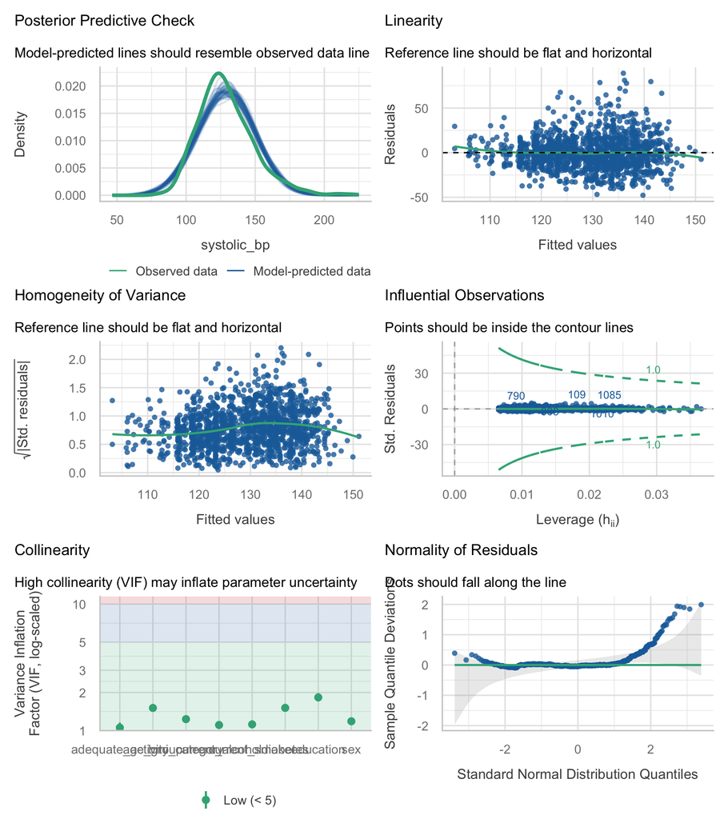

**Table 4. HC3 heteroscedasticity-consistent standard errors.**

| Term | Estimate | SE (OLS) | SE (HC3) | 95% CI (HC3) | p (HC3) |
| --- | --- | --- | --- | --- | --- |
| age_group18-25 | -3.09 | 2.184 | 1.597 | -6.22 to 0.04 | 0.053 |
| age_group36-45 | 3.12 | 1.584 | 1.378 | 0.42 to 5.82 | 0.024 |
| age_group46-55 | 10.86 | 1.638 | 1.682 | 7.56 to 14.16 | 0.000 |
| age_group56-65 | 12.19 | 1.724 | 1.725 | 8.81 to 15.58 | 0.000 |
| age_group>65 | 14.67 | 1.845 | 1.863 | 11.02 to 18.33 | 0.000 |
| sexMale | 2.90 | 1.087 | 1.082 | 0.77 to 5.02 | 0.008 |
| educationPrimary | 6.28 | 2.037 | 2.459 | 1.45 to 11.10 | 0.011 |
| educationSecondary | 4.03 | 1.992 | 2.267 | -0.42 to 8.47 | 0.076 |
| educationTertiary | -0.27 | 1.980 | 2.179 | -4.54 to 4.01 | 0.903 |
| bmi_categoryUnderweight | -10.05 | 2.263 | 2.149 | -14.26 to -5.83 | 0.000 |
| bmi_categoryOverweight | 2.66 | 1.214 | 1.280 | 0.15 to 5.18 | 0.038 |
| bmi_categoryObese | 7.32 | 1.389 | 1.333 | 4.71 to 9.94 | 0.000 |
| current_smokerYes | -0.41 | 2.141 | 2.197 | -4.72 to 3.90 | 0.851 |
| current_alcoholYes | 3.03 | 1.900 | 1.849 | -0.59 to 6.66 | 0.101 |
| adequate_activityYes | 0.38 | 1.028 | 1.029 | -1.64 to 2.40 | 0.709 |
| diabetesyes | 0.75 | 1.529 | 1.487 | -2.17 to 3.67 | 0.614 |
| diabetesunknown | 1.16 | 1.545 | 1.746 | -2.27 to 4.58 | 0.507 |

Because non-constant variance was detected, Table 4 reports HC3 robust standard errors. Point estimates are unchanged by construction; only the uncertainty is re-estimated. The HC3 standard errors differ from the OLS ones by at most 27% (for age_group18-25), and 1 coefficients change significance status under robust inference. The substantive conclusions - age, obesity and sex in, diabetes and behaviour out - are unaffected by the variance assumption.

## Sensitivity analysis: prior diagnosis and treatment

Participants who report a previous hypertension diagnosis average 141.6 mmHg against 123.9 mmHg in those who do not, and adding `prior_htn_diagnosis` to the model gives an adjusted difference of 12.4 mmHg (95% CI 10.0 to 14.7, p < 0.001) with R-squared rising to 0.240. **This coefficient must not be read as an effect of diagnosis on blood pressure.** It runs in both directions at once: being diagnosed is a consequence of having had high pressure in the past (pushing the coefficient up), while diagnosis leads to antihypertensive treatment which lowers measured pressure (pushing it down). The file contains **no medication variable at all**, so the two cannot be separated, and the observed positive coefficient is best read as evidence that treatment in this population is not bringing pressure back to the level of the undiagnosed. It is reported here as a sensitivity analysis and excluded from the main model.

# Discussion

In this Kenyan outpatient sample, age band, BMI category and sex are the characteristics independently associated with systolic blood pressure. Adjusted for the other seven predictors, the over-65s average 14.67 mmHg (95% CI 11.05 to 18.29) higher pressure than 26-35 year olds and obese participants 7.32 mmHg (95% CI 4.60 to 10.05) higher than healthy-weight participants. The crude association with self-reported diabetes, which looked substantial and highly significant, is almost entirely explained by the age and adiposity differences between participants with and without diabetes. Practically, this supports age and body size as the two variables that should drive who is offered opportunistic screening in these facilities, and it warns that a crude comparison of pressure across diabetes status or education will badly mislead.

**Limitations.** This is a **facility-based convenience sample** of people attending outpatient clinics, not a community sample: attenders are sicker and, here, far better educated than the Kenyan adult population, so no prevalence or mean from this file can be generalised to Kenya. The design is **cross-sectional**, so nothing establishes temporality and no causal claim is warranted. **No predictor is continuous**: age is banded and BMI is supplied only as a WHO category, so residual confounding within band is guaranteed and no per-unit effect can be estimated. **Antihypertensive medication is not recorded**, which is the single most serious unmeasured confounder in an analysis of measured blood pressure - treated participants have lower measured pressure precisely because their underlying risk is higher, which biases the diabetes, obesity and age coefficients toward the null by an unknown amount. Participants were recruited from **three facilities but no facility identifier is present** beyond the three-level `study_site` label, so the correlation between participants attending the same facility cannot be modelled and the standard errors reported here, robust or not, are likely too small. Complete-case analysis dropped 68 rows; `monthly_income` was excluded because including it would have cost a further 408 rows for no gain, but that means household economic position is simply unadjusted for. Sodium intake, family history, kidney function and stress are all absent. Finally, 18% explained variance means that most of the variation in systolic pressure in this sample is not captured by any measured characteristic.

**Future work.** Refit with continuous age and measured BMI, a facility identifier for a mixed-effects model, and a medication variable, none of which this extract carries.

# Feasibility notes

*NOT part of a student report.*

- **Works well as a student project.** Continuous, fully observed outcome (0 missing values), 1376 complete cases, one unambiguous dominant signal (age) plus a second clean one (BMI category), and at least two predictors that collapse on adjustment. That is exactly the Purpose 3 teaching shape.
- **FATAL trap: `hypertension` must never be a predictor here.** `hypertension` is defined *from* the measured average blood pressure. Putting it on the right-hand side is regressing the outcome on a threshold version of itself; it will produce a large R-squared and a meaningless model. `diastolic_bp` is the same measurement’s other half (r = 0.71) and must also stay out. Both need calling out in the brief.
- **THE missing-data teaching case.** `monthly_income` is 31.4% missing and listwise deletion drops the sample from 1376 to 968 (67% of the file) for a variable that contributes nothing (p = 0.982). Missingness is strongly patterned by facility (48% private vs 18% faith) and by education, so it is not MCAR. This is the best missing-data example in the catalogue and should be a required part of the brief.
- **No continuous predictors exist in this file.** Age is banded, BMI is categorised. Students will try to report “mmHg per kg/m2” or “per year of age” and cannot. The model is a cell-means model; say so up front.
- **Heteroscedasticity is real and flagged (p < 0.001)** with a heavy right tail. Good: it gives a genuine reason to run `check_heteroscedasticity()` and HC3, and the conclusions survive (1 significance flips).
- **`current_smoker` is sparse**: 93 smokers in the whole file, 81 of 89 of them men. The coefficient is imprecise and largely a sex contrast. Keep it to one degree of freedom and do not interact it with anything.
- **`bmi_category` “Underweight” is thin** (80 in the analytic sample) and the strongly negative underweight coefficient is probably reverse causation (illness-related weight loss), not protection.
- **Clustering cannot be modelled.** Three facilities, no facility ID, so `study_site` is the only handle and a random effect is impossible. Standard errors are optimistic.
- **Modest R-squared (0.180)** will disappoint students who expect a “good” model; pre-empt it.
- No separation, no collinearity (max VIF 1.83), no influential-point problems.